# HW4

Omer Abuhatzira, Eden Malka, Salome Baranes

2025-05-02

Group members:

- Omer Abuhazira 319119988 omer.abuhatzira@mail.huji.ac.il
- Eden Malka 318849940 eden.malka@mail.huji.ac.il
- Salome Baranes 209891183 salome.baranes@mail.huji.ac.il

### Libraries used

```r
# Load necessary libraries
library(data.table)
library(ggplot2)
library(splines)
library(dplyr)
library(tidyr)
```

### Paths and Data - Data Preparation

```r
library(data.table)

# The read mapping file (from last week's lab)
reads_file <- "C:/Users/salom/Downloads/TCGA-13-0723-01A_lib1_all_chr1.forward"
chr1_reads <- fread(reads_file)
colnames(chr1_reads) <- c("Chrom", "Loc", "FragLen")

# Load and concatenate the full chromosome 1 sequence from 5 parts
load_rda_string <- function(path) {
  obj_name <- load(path)
  get(obj_name)
}

# Load each .rda file
s1 <- load_rda_string("C:/Users/salom/Downloads/chr1_str_0M_50M.rda")
s2 <- load_rda_string("C:/Users/salom/Downloads/chr1_str_50M_100M.rda")
s3 <- load_rda_string("C:/Users/salom/Downloads/chr1_str_100M_150M.rda")
s4 <- load_rda_string("C:/Users/salom/Downloads/chr1_str_150M_200M.rda")
s5 <- load_rda_string("C:/Users/salom/Downloads/chr1_str_200M_end.rda")

# Concatenate to get the full chr1 sequence as a single character string
chr1_seq <- paste0(s1, s2, s3, s4, s5)

# Split into individual bases (A, C, G, T)
chr1_full <- strsplit(chr1_seq, "")[[1]]

# Check length (should be ~250 million)
length(chr1_full)
```

```
## [1] 247249719
```

### Introduction

In this lab, we investigate the relationship between GC content and sequencing coverage along human chromosome 1 using **non-parametric regression**, with a focus on spline-based models. We compute GC and coverage profiles in 10K bp bins and apply **outlier filtering** to focus on the central distribution. Through an **iterative process** combining **visual intuition** and **robust statistical summaries**, we aim to capture the core structure of the data while identifying and correcting systematic GC-related biases. We emphasize the use of **cubic splines** to flexibly model non-linear trends in coverage across the GC spectrum.

### Question a: Relationship Between GC Content and Coverage

#### Modeling GC-Coverage Relationship with LOESS – Initial Exploration

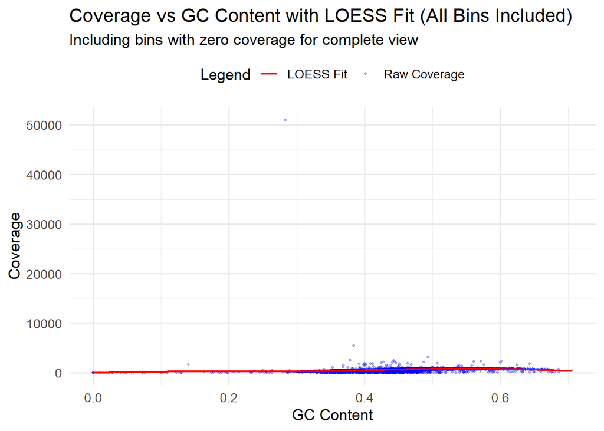

```r
library(ggplot2)

# Define bin size
bin_size <- 10000
n_bins <- floor(length(chr1_full) / bin_size)

# Calculate GC content for each bin
GC_per_bin <- numeric(n_bins)
for (i in 1:n_bins) {
  bin <- chr1_full[((i - 1) * bin_size + 1):(i * bin_size)]
  GC_per_bin[i] <- sum(bin %in% c("G", "C")) / bin_size
}

# Calculate coverage (number of reads per bin)
bin_breaks <- c(seq(0, length(chr1_full) + bin_size, by = bin_size))
coverage_per_bin <- hist(chr1_reads$Loc, breaks = bin_breaks, plot = FALSE)$counts

# Align vector lengths (histogram produces one extra bin)
min_length <- min(length(GC_per_bin), length(coverage_per_bin))
GC_per_bin <- GC_per_bin[1:min_length]
coverage_per_bin <- coverage_per_bin[1:min_length]

# Build dataframe
gc_df <- data.frame(
  GC_Content = GC_per_bin,
  Coverage = coverage_per_bin
)

# Fit LOESS curve (using ALL data, even zeros)
loess_model <- loess(Coverage ~ GC_Content, data = gc_df, span = 0.5)
gc_df$loess_fit <- predict(loess_model)

# Calculate residuals from LOESS
gc_df$resid_loess <- gc_df$Coverage - gc_df$loess_fit

# Plot Coverage vs GC Content with LOESS fit
ggplot(gc_df, aes(x = GC_Content, y = Coverage)) +
  geom_point(aes(color = "Raw Coverage"), alpha = 0.3, size = 0.8) +  # Raw data points
  geom_line(aes(y = loess_fit, color = "LOESS Fit"), size = 0.8) +  # LOESS fitted curve
  scale_color_manual(name = "Legend", values = c("Raw Coverage" = "blue", "LOESS Fit" = "red")) +  # Legend colors
  labs(
    title = "Coverage vs GC Content with LOESS Fit (All Bins Included)",
    subtitle = "Including bins with zero coverage for complete view",
    x = "GC Content",
    y = "Coverage"
  ) +
  theme_minimal(base_size = 13) +
  theme(legend.position = "top")  # Legend on top
```

### Preliminary Findings from LOESS Fit

The initial LOESS regression highlights a clear association between GC content and coverage, peaking around intermediate GC values. However, the visual impression is dominated by a few extreme bins with abnormally high coverage, which stretch the y-axis and compress the informative middle range. This limits our ability to accurately interpret the trend. These findings reinforce the need to apply transition to **spline-based modeling**, which can better reflect the central structure while mitigating the influence of outliers.

[figure not shown]

[output not shown]

[output cut: 20 more lines]

[output not shown]

[figure not shown]

```r
data_for_model <- data.frame(
  GC_Content = gc_df$GC_Content,
  Coverage = gc_df$Coverage
)

smoothScatter(data_for_model$GC_Content, data_for_model$Coverage,
              ylim = c(0, 2000),
              xlab = "GC Content",
              ylab = "Coverage",
              main = "SmoothScatter: GC Content vs Coverage")
```

### Spline Regression Analysis: Quadratic vs. Cubic Fit

The plot compares **quadratic** and **cubic spline regressions** to model the relationship between GC content and coverage. Both splines **capture the main non-linear trend**, though they miss some sharper changes, especially at extreme GC levels. Coverage tends to increase around **GC = 0.4–0.5** and then decline, which reflects known **sequencing biases** in GC-poor and GC-rich regions.

Additionally, since some bins show extremely high coverage values, we limited the Y-axis in the plot for visualization purposes only. This allows us to better observe and compare the central trends of the spline models without the graph being skewed by extreme outliers.

While the **R² values are nearly identical (R² ≈ 0.271)**, the **cubic spline shows better flexibility** and captures local variations more effectively, particularly at lower and higher GC content. In contrast, the quadratic spline gives a smoother and simpler view of the overall trend.

Given these results, **we chose to continue with the cubic spline** as it provides a better representation of subtle fluctuations in coverage, which may be important for downstream analysis.

### Detecting Outliers via LOESS Residuals

In this step, we smooth the coverage across chromosome 1 using a LOESS curve, then compute residuals to identify **local outliers**. Bins with unusually high or low coverage—beyond ±1.5×IQR of the residuals—are flagged and visualized, highlighting deviations from the local trend without assuming a global model.

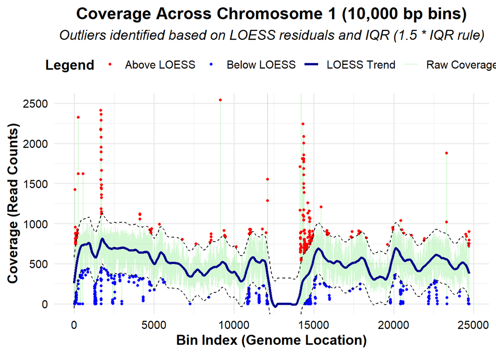

```r
library(data.table)
library(ggplot2)

# Define bin size
bin_size <- 10000
n_bins <- ceiling(length(chr1_full) / bin_size)

# Calculate coverage (number of reads per bin)
bin_breaks <- c(seq(0, length(chr1_full) + bin_size, by = bin_size))
coverage <- hist(chr1_reads$Loc, breaks = bin_breaks, plot = FALSE)$counts

# Prepare dataframe
df <- data.frame(
  Bin = seq_along(coverage),
  Coverage = coverage
)

# Smooth coverage using LOESS
smoothed_line <- loess(Coverage ~ Bin, data = df, span = 0.05)
df$Smoothed <- predict(smoothed_line)

# Calculate residuals
df$Residual <- df$Coverage - df$Smoothed

# Calculate IQR from residuals
Q1 <- quantile(df$Residual, 0.25)
Q3 <- quantile(df$Residual, 0.75)
IQR_val <- Q3 - Q1

upper_threshold <- Q3 + 1.5 * IQR_val
lower_threshold <- Q1 - 1.5 * IQR_val

# Define upper and lower outliers
df$OutlierType <- "None"
df$OutlierType[df$Residual > upper_threshold] <- "Above LOESS"
df$OutlierType[df$Residual < lower_threshold] <- "Below LOESS"

# Final plot
ggplot(df, aes(x = Bin, y = Coverage)) +
  geom_line(aes(color = "Raw Coverage"), alpha = 0.4, linewidth = 0.5) +
  geom_point(data = subset(df, OutlierType == "Above LOESS"), aes(color = "Above LOESS"), size = 1) +
  geom_point(data = subset(df, OutlierType == "Below LOESS"), aes(color = "Below LOESS"), size = 1) +
  geom_line(aes(y = Smoothed, color = "LOESS Trend"), linewidth = 1.2) +
  geom_line(aes(y = Smoothed + upper_threshold), color = "black", linetype = "dashed", linewidth = 0.5) +
  geom_line(aes(y = Smoothed + lower_threshold), color = "black", linetype = "dashed", linewidth = 0.5) +
  scale_color_manual(name = "Legend",
                     values = c("Raw Coverage" = "lightgreen",
                                "Above LOESS" = "red",
                                "Below LOESS" = "blue",
                                "LOESS Trend" = "darkblue")) +
  labs(
    title = "Coverage Across Chromosome 1 (10,000 bp bins)",
    subtitle = "Outliers identified based on LOESS residuals and IQR (1.5 * IQR rule)",
    x = "Bin Index (Genome Location)",
    y = "Coverage (Read Counts)"
  ) +
  coord_cartesian(ylim = c(0, 2500)) +
  theme_minimal(base_size = 14) +
  theme(
    plot.title = element_text(face = "bold", hjust = 0.5),
    plot.subtitle = element_text(face = "italic", hjust = 0.5),
    axis.title = element_text(face = "bold"),
    axis.text = element_text(color = "black"),
    legend.position = "top",
    legend.title = element_text(face = "bold")
  )
```

```r
# Create clean dataset without outliers for further use
df_clean <- df[df$OutlierType == "None", ]
```

### Outlier Detection

The plot above shows how this method helps reveal outliers in coverage. By focusing on residuals from the LOESS fit and applying the 1.5×IQR rule, we detect bins that clearly stand out from their local trend.

By fitting a smooth local trend and applying the **1.5×IQR rule** to the residuals, we isolate bins that deviate substantially from their local context rather than from the median.

This approach is particularly well-suited to genomic data, where coverage patterns vary along the chromosome and global thresholds may miss context-specific anomalies. The outliers identified—highlighted in red and blue—are strong candidates for removal in the next regression step, as they are likely to distort the fit without contributing meaningful signal.

### Fitting Cubic Spline after Outlier Removal

After detecting and removing local outliers based on LOESS residuals and the 1.5×IQR rule, we proceeded to refit the cubic spline model on the cleaned dataset. This step is crucial because outliers, especially in genomic data, can disproportionately influence the fit and obscure the underlying relationship between GC content and coverage.

For the spline fitting, we carefully selected knots based on the GC content distribution. Specifically, we placed the knots at the 20th, 30th, 50th, and 60th percentiles of GC content. This choice reflects the areas in which the relationship between GC content and coverage changes most rapidly, as observed in our earlier visualizations.

By focusing knots within this key range, we allow the model to remain flexible where necessary while avoiding overfitting in flatter regions with minimal variation.

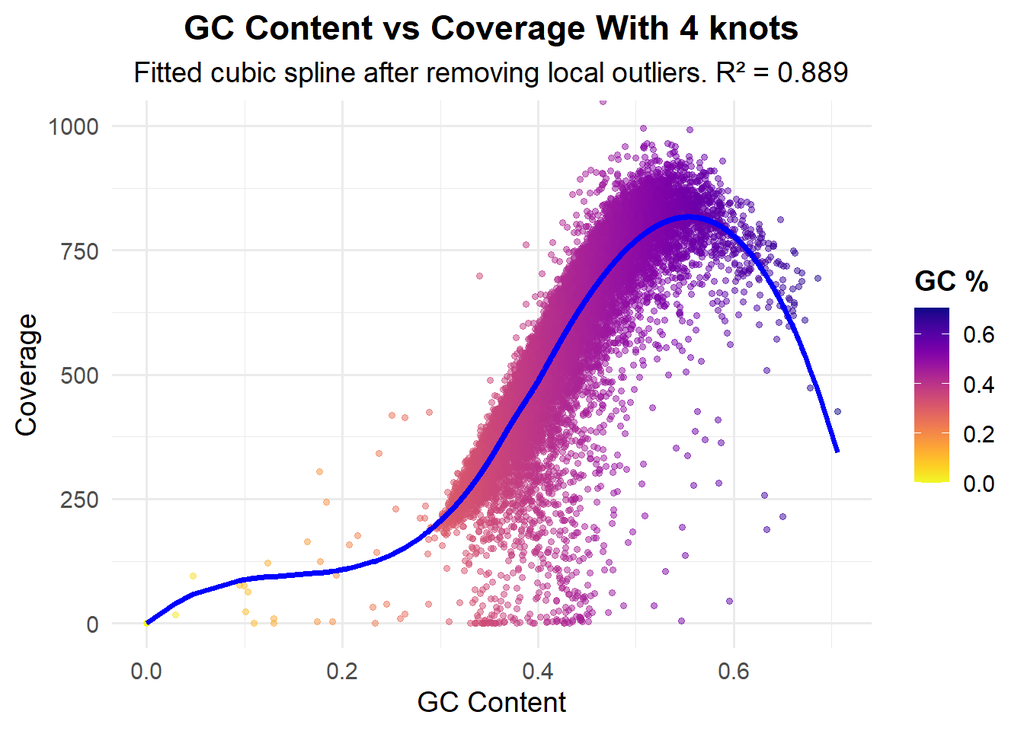

```r
library(viridis)
library(data.table)
library(ggplot2)
library(splines)

# Prepare Coverage Data

# Bin size
bin_size <- 10000
n_bins <- ceiling(length(chr1_full) / bin_size)

# Calculate coverage per bin
bin_breaks <- c(seq(0, length(chr1_full) + bin_size, by = bin_size))
coverage <- hist(chr1_reads$Loc, breaks = bin_breaks, plot = FALSE)$counts

# Create dataframe
df <- data.frame(
  Bin = seq_along(coverage),
  Coverage = coverage
)

# Detect Outliers using LOESS residuals

# Smooth coverage with LOESS
loess_model <- loess(Coverage ~ Bin, data = df, span = 0.05)
df$Smoothed <- predict(loess_model)

# Calculate residuals
df$Residual <- df$Coverage - df$Smoothed

# Calculate IQR and identify outliers
Q1 <- quantile(df$Residual, 0.25)
Q3 <- quantile(df$Residual, 0.75)
IQR_val <- Q3 - Q1
upper_threshold <- Q3 + 1.5 * IQR_val
lower_threshold <- Q1 - 1.5 * IQR_val

# Mark outliers
df$OutlierType <- "None"
df$OutlierType[df$Residual > upper_threshold] <- "Above LOESS"
df$OutlierType[df$Residual < lower_threshold] <- "Below LOESS"

# Create cleaned dataframe without outliers (this will be used for spline)
df_clean <- df[df$OutlierType == "None", ]

# Add GC Content to Cleaned Data

# Calculate GC content for each bin
GC_per_bin <- numeric(n_bins)
for (i in 1:n_bins) {
  bin <- chr1_full[((i - 1) * bin_size + 1):(i * bin_size)]
  GC_per_bin[i] <- sum(bin %in% c("G", "C")) / bin_size
}

# Add GC content to cleaned dataframe
df_clean$GC_Content <- GC_per_bin[df_clean$Bin]

# Step 4: Fit Cubic Spline on Clean Data

# Define knots
knots_gc <- quantile(df_clean$GC_Content, probs = c(0.2, 0.3, 0.5, 0.6))

# Fit cubic spline
cubic_model <- lm(Coverage ~ bs(GC_Content, knots = knots_gc, degree = 3), data = df_clean)
df_clean$Cubic_Fit <- predict(cubic_model)

# Calculate R-squared
r2_cubic <- round(summary(cubic_model)$r.squared, 3)

# Plot GC Content vs Coverage with Cubic Spline

ggplot(df_clean, aes(x = GC_Content, y = Coverage)) +
  geom_point(aes(color = GC_Content), alpha = 0.5, size = 1.2) +
  geom_line(aes(y = Cubic_Fit), color = "blue", size = 1.3) +
  scale_color_viridis(name = "GC %", option = "plasma", direction = -1) +
  coord_cartesian(ylim = c(0, 1000)) +
  labs(
    title = "GC Content vs Coverage With 4 knots",
    subtitle = paste0("Fitted cubic spline after removing local outliers. R² = ", r2_cubic),
    x = "GC Content",
    y = "Coverage"
  ) +
  theme_minimal(base_size = 14) +
  theme(
    legend.position = "right",
    legend.title = element_text(face = "bold"),
    plot.title = element_text(face = "bold", hjust = 0.5),
    plot.subtitle = element_text(hjust = 0.5)
  )
```

```r
# Calculate RMSE

# Calculate residuals (differences between observed and predicted values)
residuals <- df_clean$Coverage - df_clean$Cubic_Fit

# Calculate RMSE
rmse <- sqrt(mean(residuals^2))

# Print RMSE
print(paste("RMSE:", round(rmse, 2)))
```

```
## [1] "RMSE: 74.23"
```

### Cubic Spline Fit After Outlier Removal

The fitted curve captures the main pattern well: it follows the sharp increase at moderate GC levels and the decline at higher GC values, without being overly affected by outliers.

### Model Fit

The model reached a strong fit (**R² = 0.889**), reflecting a balance between flexibility and stability in capturing the relationship between GC content and coverage. To complement the R-squared value, we also calculated the Root Mean Squared Error (RMSE), which was **74.23**. This indicates that, on average, the predicted coverage values deviate from the observed values by approximately 74 reads. Given that coverage values in the dataset reach up to around 1000, this error is considered modest.

Together, the high R-squared and relatively low RMSE suggest that the cubic spline model fits the cleaned data well and effectively captures the overall trend, while accounting for the natural variability inherent in genomic coverage data. **This fit will be used for the residual analysis.**

### Part b: Residual Analysis

To assess how well the cubic spline model fits the data after removing outliers, we plotted the residuals against GC content. This helps check whether there is any remaining pattern or bias the model did not capture. Ideally, residuals should be spread randomly around zero across all GC values, which would suggest that the model explains most of the systematic variation in coverage.

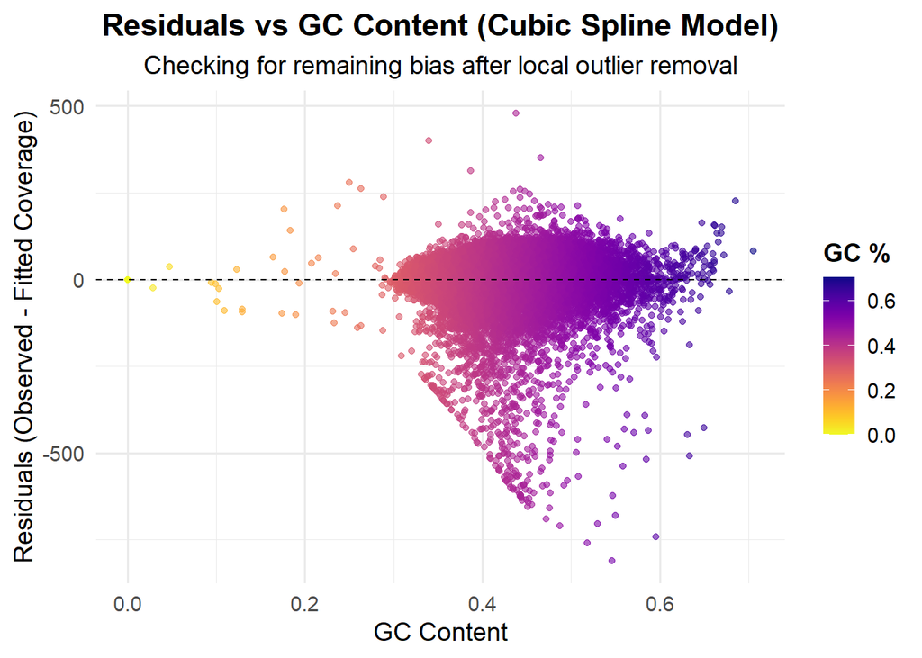

```r
library(ggplot2)
library(viridis)

# Calculate residuals
df_clean$Residuals <- df_clean$Coverage - df_clean$Cubic_Fit

# Plot residuals vs GC Content with color scale by GC
ggplot(df_clean, aes(x = GC_Content, y = Residuals, color = GC_Content)) +
  geom_point(alpha = 0.6, size = 1.5) +
  geom_hline(yintercept = 0, color = "black", linetype = "dashed") +
  scale_color_viridis(
    option = "plasma",
    name = "GC %",
    direction = -1
  ) +
  labs(
    title = "Residuals vs GC Content (Cubic Spline Model)",
    subtitle = "Checking for remaining bias after local outlier removal",
    x = "GC Content",
    y = "Residuals (Observed - Fitted Coverage)"
  ) +
  theme_minimal(base_size = 14) +
  theme(
    plot.title = element_text(face = "bold", hjust = 0.5),
    plot.subtitle = element_text(hjust = 0.5),
    legend.title = element_text(face = "bold")
  )
```

### Residual Analysis (After Local Outlier Removal via LOESS and IQR)

Ideally, the residuals should form a random, structureless “cloud” scattered around zero across the entire GC range. However, this is clearly not the case here.

Moreover, we observe *heteroskedasticity*—the residual spread varies across the GC axis. In particular, the variance is much larger in the lower-middle GC range, forming a fan-shaped structure, while it narrows toward the higher GC end. This violates the assumption of constant error variance and implies that prediction uncertainty is not uniform.

A potential biological explanation could be related to the nature of the sequenced region. If this area includes genes associated with cancer, it is possible that **genomic instability, fragmentation, or poor mapping efficiency** reduced the actual coverage, particularly in GC-balanced regions. Such biological and technical artifacts often disrupt uniform sequencing and can lead to systematic deviations like those observed here.

In summary, the residual pattern indicates that despite improving the model by removing outliers, **some structured bias remains**, likely driven by a combination of model limitations and inherent biological variability.

### Part A again- Trimming GC Extremes

In this step, we re-estimate the spline model after **excluding extreme GC content values**—specifically, bins with GC content below 0.2 or above 0.65. This focused modeling region was chosen based on the previous residual plot, which showed instability at the edges. By restricting the fit to the more stable central range, we aim to reduce edge-related distortions and improve the overall model calibration.

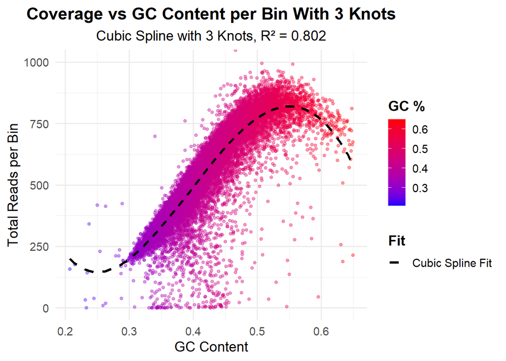

```r
library(data.table)
library(ggplot2)
library(splines)

# --- Prepare Coverage Data ---
bin_size <- 10000
n_bins <- ceiling(length(chr1_full) / bin_size)
bin_breaks <- c(seq(0, length(chr1_full) + bin_size, by = bin_size))
coverage <- hist(chr1_reads$Loc, breaks = bin_breaks, plot = FALSE)$counts

df <- data.frame(
  Bin = seq_along(coverage),
  Coverage = coverage
)

# --- Detect Outliers using LOESS residuals ---
loess_model <- loess(Coverage ~ Bin, data = df, span = 0.05)
df$Smoothed <- predict(loess_model)
df$Residual <- df$Coverage - df$Smoothed

Q1 <- quantile(df$Residual, 0.25)
Q3 <- quantile(df$Residual, 0.75)
IQR_val <- Q3 - Q1
upper_threshold <- Q3 + 1.5 * IQR_val
lower_threshold <- Q1 - 1.5 * IQR_val

df$OutlierType <- "None"
df$OutlierType[df$Residual > upper_threshold] <- "Above LOESS"
df$OutlierType[df$Residual < lower_threshold] <- "Below LOESS"

df_clean <- df[df$OutlierType == "None", ]

# --- Add GC Content to Cleaned Data ---
GC_per_bin <- numeric(n_bins)
for (i in 1:n_bins) {
  bin <- chr1_full[((i - 1) * bin_size + 1):(i * bin_size)]
  GC_per_bin[i] <- sum(bin %in% c("G", "C")) / bin_size
}
df_clean$GC_Content <- GC_per_bin[df_clean$Bin]

# --- FILTER to GC Content between 0.2 and 0.65 ---
df_model <- df_clean[df_clean$GC_Content >= 0.2 & df_clean$GC_Content <= 0.65, ]

# --- Fit Cubic Spline ---
knots_gc <- quantile(df_model$GC_Content, probs = c(0.3, 0.4, 0.55))
cubic_model <- lm(Coverage ~ bs(GC_Content, knots = knots_gc, degree = 3), data = df_model)
df_model$Cubic_Fit <- predict(cubic_model)

r2_cubic <- round(summary(cubic_model)$r.squared, 3)

# --- Plot GC Content vs Coverage with Cubic Spline ---

library(ggplot2)
library(ggnewscale)  # Required to use multiple color scales in one plot

ggplot(df_model, aes(x = GC_Content, y = Coverage)) +
  # Color points by GC Content (continuous gradient)
  geom_point(aes(color = GC_Content), alpha = 0.4, size = 1.2) +
  scale_color_gradient(low = "blue", high = "red", name = "GC %") +

  # Separate color scale for the next layer
  ggnewscale::new_scale_color() +

  # Add black dashed line with a separate legend
  geom_line(aes(y = Cubic_Fit, color = "Cubic Spline Fit"), linetype = "dashed", size = 1.2) +
  scale_color_manual(name = "Fit", values = c("Cubic Spline Fit" = "black")) +

  # Additional plot elements
  coord_cartesian(ylim = c(0, 1000)) +
  labs(
    title = "Coverage vs GC Content per Bin With 3 Knots",
    subtitle = paste0("Cubic Spline with 3 Knots, R² = ", r2_cubic),
    x = "GC Content",
    y = "Total Reads per Bin"
  ) +
  theme_minimal(base_size = 14) +
  theme(
    legend.position = "right",
    legend.title = element_text(face = "bold"),
    plot.title = element_text(face = "bold", hjust = 0.5),
    plot.subtitle = element_text(hjust = 0.5)
  )
```

```r
# Calculate residuals (observed - predicted)
residuals <- df_model$Coverage - df_model$Cubic_Fit

# Calculate RMSE
rmse <- sqrt(mean(residuals^2))

# Print RMSE
print(paste("RMSE:", round(rmse, 2)))
```

```
## [1] "RMSE: 77.59"
```

### GC Content vs Coverage (Cubic Spline, Middle GC Focus) — Summary

In this step, we focused our spline fitting on a **central GC content range (0.2–0.65)** to avoid instability and extreme behavior at the edges. The fitted curve now appears to follow the main structure of the data more smoothly, especially in the dense middle region, and avoids the abrupt downturns seen before.

However, despite the better alignment in the core area, the **R² value decreased**. This happens because R² reflects the proportion of the total variance explained across the whole dataset — and by trimming the extreme GC bins (where variance was very low or very high), we removed parts that were easier to explain or fit tightly. This makes the model relatively less “powerful” in explaining the variability of the remaining (and harder-to-fit) data.

In short, while the visual fit and model calibration improved for the central GC range — which was our goal — the overall R² went down slightly because we are now modeling a narrower and more challenging slice of the data.

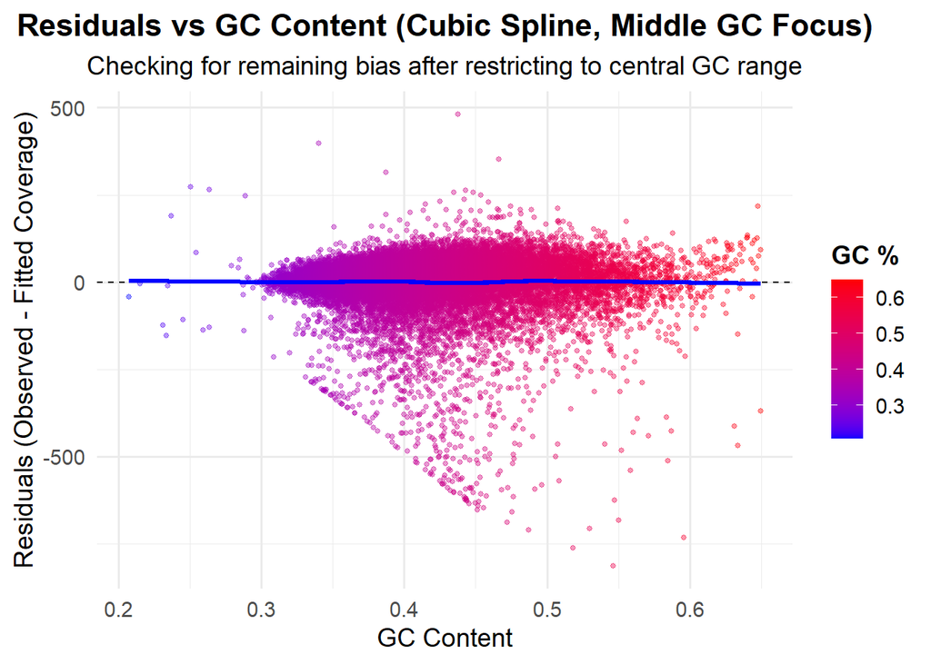

```r
df_model$Residual <- df_model$Coverage - df_model$Cubic_Fit

ggplot(df_model, aes(x = GC_Content, y = Residual)) +
  geom_point(aes(color = GC_Content), alpha = 0.4, size = 1) +
  geom_hline(yintercept = 0, linetype = "dashed") +
  geom_smooth(method = "loess", se = FALSE, color = "blue", size = 1.2) +
  scale_color_gradient(low = "blue", high = "red", name = "GC %") +
  labs(
    title = "Residuals vs GC Content (Cubic Spline, Middle GC Focus)",
    subtitle = "Checking for remaining bias after restricting to central GC range",
    x = "GC Content",
    y = "Residuals (Observed - Fitted Coverage)"
  ) +
  theme_minimal(base_size = 14) +
  theme(
    plot.title = element_text(face = "bold", hjust = 0.5),
    plot.subtitle = element_text(hjust = 0.5),
    legend.title = element_text(face = "bold")
  ) +
  guides(color = guide_colorbar(title = "GC %"),
         linetype = guide_legend(title = "Trend Line")) +
  geom_line(data = df_model, aes(x = GC_Content, y = predict(loess(Residual ~ GC_Content))), color = "blue", size = 1.2)
```

### Residual Analysis After Focusing on Central GC Range

#### Quantile-Based Residual Outlier Detection and Removal

To further refine the residual pattern, a quantile-based outlier removal procedure was applied. Specifically, residuals exceeding the 99th percentile or falling below the 1st percentile within each GC bin were flagged as outliers and removed. In the plot below, these outliers are highlighted in black on top of the original residual distribution.

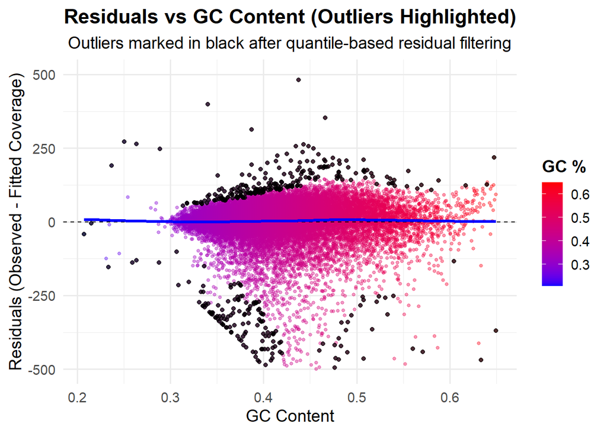

```r
library(dplyr)
library(ggplot2)

# Calculate residuals
df_model$Residual <- df_model$Coverage - df_model$Cubic_Fit

# Create GC bins (same bins as used in the plots)
df_model$GC_Bin <- cut(df_model$GC_Content, breaks = seq(0.2, 0.7, by = 0.02), include.lowest = TRUE)

# Make GC_Bin character to avoid join issues
df_model$GC_Bin <- as.character(df_model$GC_Bin)

# Calculate 1% and 99% quantiles for each GC bin
quantile_thresholds <- df_model %>%
  group_by(GC_Bin) %>%
  summarise(
    lower = quantile(Residual, 0.01, na.rm = TRUE),
    upper = quantile(Residual, 0.99, na.rm = TRUE)
  )

# Make GC_Bin in quantile_thresholds character as well
quantile_thresholds$GC_Bin <- as.character(quantile_thresholds$GC_Bin)

# Join thresholds back to df_model
df_model <- left_join(df_model, quantile_thresholds, by = "GC_Bin")

# Flag outliers
df_model$Outlier_Bin <- df_model$Residual < df_model$lower | df_model$Residual > df_model$upper

# Plot residuals vs GC Content with outliers in black
ggplot(df_model, aes(x = GC_Content, y = Residual)) +
  # Regular residual points
  geom_point(aes(color = GC_Content), alpha = 0.4, size = 1) +

  # Zero line
  geom_hline(yintercept = 0, linetype = "dashed") +

  # LOESS trend
  geom_smooth(method = "loess", se = FALSE, color = "blue", size = 1.2) +

  # Color scale
  scale_color_gradient(low = "blue", high = "red", name = "GC %") +

  # Y limits
  scale_y_continuous(limits = c(-500, 500)) +

  # Titles and labels
  labs(
    title = "Residuals vs GC Content (Outliers Highlighted)",
    subtitle = "Outliers marked in black after quantile-based residual filtering",
    x = "GC Content",
    y = "Residuals (Observed - Fitted Coverage)"
  ) +

  theme_minimal(base_size = 14) +
  theme(
    plot.title = element_text(face = "bold", hjust = 0.5),
    plot.subtitle = element_text(hjust = 0.5),
    legend.title = element_text(face = "bold")
  ) +

  guides(color = guide_colorbar(title = "GC %")) +

  # Outliers in black
  geom_point(data = df_model %>% filter(Outlier_Bin),
             aes(x = GC_Content, y = Residual),
             color = "black", size = 1.5, alpha = 0.7)
```

### Part c: Residual Spread Across GC Bins – Final Evaluation

```r
# Calculate residuals BEFORE residual filtering (on full data)
df_model$residual_before <- df_model$Coverage - df_model$Cubic_Fit

# Create df_model_filtered: remove outliers based on previous IQR filtering
df_model_filtered <- df_model %>% filter(!Outlier_Bin)

# Calculate residuals AFTER residual filtering
df_model_filtered$residual_after <- df_model_filtered$Coverage - predict(cubic_model, newdata = df_model_filtered)

# Helper function to calculate IQR
IQR_val <- function(x) quantile(x, 0.75, na.rm = TRUE) - quantile(x, 0.25, na.rm = TRUE)

# Summarize residuals: Median, IQR, MAD, SD
residual_summary <- data.frame(
  Metric = c("Median", "IQR", "MAD", "SD"),
  Before = c(
    median(df_model$residual_before, na.rm = TRUE),
    IQR_val(df_model$residual_before),
    mad(df_model$residual_before, na.rm = TRUE),
    sd(df_model$residual_before, na.rm = TRUE)
  ),
  After = c(
    median(df_model_filtered$residual_after, na.rm = TRUE),
    IQR_val(df_model_filtered$residual_after),
    mad(df_model_filtered$residual_after, na.rm = TRUE),
    sd(df_model_filtered$residual_after, na.rm = TRUE)
  )
)

# Display the summary table
print(residual_summary)
```

```
##   Metric   Before    After
## 1 Median 11.60524 11.61345
## 2    IQR 55.91887 54.47153
## 3    MAD 41.36064 40.14976
## 4     SD 77.59484 61.82172
```

### Residual Diagnostics – Summary Statistics

In this stage of the analysis, we compared the residual spread **before and after applying quantile-based residual outlier removal**. This comparison highlights the impact of removing extreme residuals identified within GC bins.

This indicates that the extreme values had a substantial impact on the variability of the residuals prior to filtering. By removing these outliers, the residual distribution became tighter and more symmetric, improving the model’s ability to capture the underlying relationship without being influenced by extreme deviations.

### Question c: Residual Spread Across GC Content Values

These results highlight that even after cleaning outliers and fitting a spline, some **non-constant variance** remains across the GC range. While not extreme, this is important to consider when modeling sequencing bias and assessing model fit.

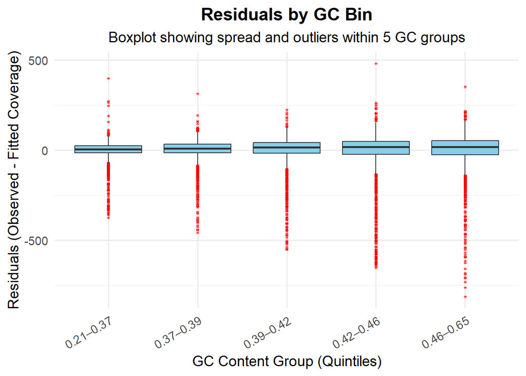

```r
library(ggplot2)
library(dplyr)

# Calculate residuals if not already done
df_model$Residual <- df_model$Coverage - df_model$Cubic_Fit

# Create 5 GC content bins using quantiles and generate rounded numeric labels
gc_breaks <- quantile(df_model$GC_Content, probs = seq(0, 1, length.out = 6), na.rm = TRUE)
labels_gc <- paste0(round(gc_breaks[-6], 2), "–", round(gc_breaks[-1], 2))

df_model$GC_Bin_5 <- cut(
  df_model$GC_Content,
  breaks = gc_breaks,
  include.lowest = TRUE,
  labels = labels_gc
)

# Generate boxplot
ggplot(df_model, aes(x = GC_Bin_5, y = Residual)) +
  geom_boxplot(fill = "skyblue", outlier.color = "red", outlier.shape = 8, outlier.size = 0.5) +
  labs(
    title = "Residuals by GC Bin",
    subtitle = "Boxplot showing spread and outliers within 5 GC groups",
    x = "GC Content Group (Quintiles)",
    y = "Residuals (Observed - Fitted Coverage)"
  ) +
  theme_minimal(base_size = 14) +
  theme(
    plot.title = element_text(face = "bold", hjust = 0.5),
    plot.subtitle = element_text(hjust = 0.5),
    axis.text.x = element_text(angle = 30, hjust = 1)
  )
```

### Residual Spread Analysis by GC Content Bins

The boxplot above visualizes the distribution of residuals across five defined GC content bins. Each bin represents a different range of GC percentages, allowing us to observe how the residual spread changes as GC content increases.

Across all bins, the majority of residuals are centered around zero, indicating that the cubic spline model generally fits well across the GC spectrum. This is reflected by the medians of the boxplots, which remain close to the zero line in all groups.

However, the spread of the residuals slightly increases in higher GC content bins. This can be observed by the taller boxes and the more pronounced presence of outliers in the upper bins. These outliers, marked in red, become more frequent and extreme as GC content increases, especially in the last two bins. This suggests that while the model captures the overall trend, it becomes less precise at the higher GC ranges, leading to more variability.

### Residuals vs Fitted Values

In the final step of the residual analysis, we aim to assess whether the residuals behave randomly with respect to the fitted values. A well-behaved model should show no clear pattern in this plot: residuals should be symmetrically scattered around zero, with consistent spread across all fitted values. Detecting any systematic pattern (such as curves, funnels, or clusters) would indicate potential issues like bias, non-linearity, or heteroscedasticity.

The following plot displays the residuals against the fitted values after applying our filtering and cleaning process.

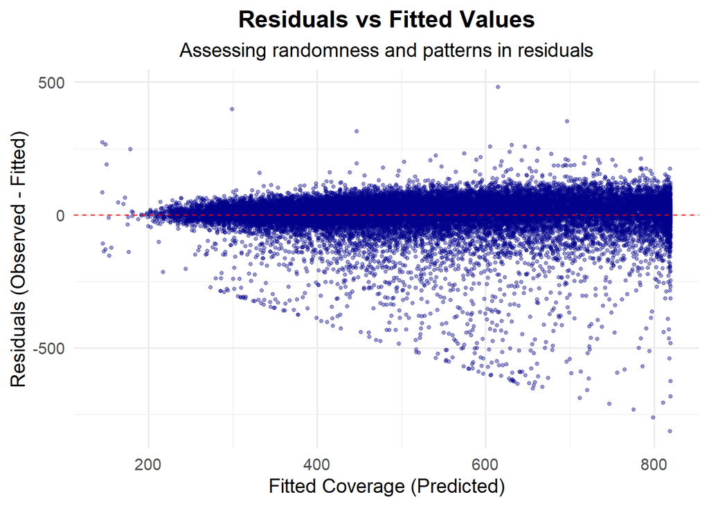

```r
library(ggplot2)

# Calculate fitted values using the cubic model
df_model$Fitted <- predict(cubic_model, newdata = df_model)

# Calculate residuals
df_model$Residual <- df_model$Coverage - df_model$Fitted

# Plot Residuals vs Fitted
ggplot(df_model, aes(x = Fitted, y = Residual)) +
  geom_point(alpha = 0.4, color = "darkblue", size = 1) +
  geom_hline(yintercept = 0, linetype = "dashed", color = "red") +
  labs(
    title = "Residuals vs Fitted Values",
    subtitle = "Assessing randomness and patterns in residuals",
    x = "Fitted Coverage (Predicted)",
    y = "Residuals (Observed - Fitted)"
  ) +
  theme_minimal(base_size = 14) +
  theme(
    plot.title = element_text(face = "bold", hjust = 0.5),
    plot.subtitle = element_text(hjust = 0.5)
  )
```

### Interpretation

The plot shows that the residuals are generally centered around zero across all fitted values, which is expected after cleaning the data.

However, it is worth noting that the spread of residuals slightly increases at higher fitted values. This pattern suggests mild heteroscedasticity — meaning the variance of the residuals becomes larger as the predicted coverage increases. This behavior is not unusual in sequencing data, where regions with higher coverage tend to be more variable.

This pattern does not indicate poor model fit but rather reflects expected biological and technical variability inherent in high coverage regions.